# Week 8 - CART and Random Forests

The United States government periodically collects demographic information by conducting a census. In this problem, you are going to use census information about an individual to predict how much a person earns - in particular, whether the person earns more than $50,000 per year. This data comes from the UCI Machine Learning Repository.

The file census.csv contains 1994 census data for 31,978 individuals in the United States. The dataset includes the following 13 variables:

 age: the age of the individual in years

 workclass: the classification of the individual’s working status (does the person work for the federal government, work for the local government, work without pay, and so on)

 education: the level of education of the individual (e.g., 5th-6th grade, high school graduate, PhD, so on)

 maritalstatus: the marital status of the individual

 occupation: the type of work the individual does (e.g., administrative/clerical work, farming/fishing, sales and so on)

 relationship: relationship of individual to his/her household

 race: the individual’s race

 sex: the individual’s sex

 capitalgain: the capital gains of the individual in 1994 (from selling an asset such as a stock or bond for more than the original purchase price)

 capitalloss: the capital losses of the individual in 1994 (from selling an asset such as a stock or bond for less than the original purchase price)

 hoursperweek: the number of hours the individual works per week

 nativecountry: the native country of the individual

 over50k: whether or not the individual earned more than $50,000 in 1994

1. Let’s begin by building a logistic regression model to predict whether an individual’s earnings are above $50,000 (the variable 50k“) using all of the other variables as independent variables. Split the data randomly into a training set and a testing set, setting the seed to 2000 before creating the split.
- Split the data so that the training set contains 60% of the observations, while the testing set contains 40% of the observations.
- Next, build a logistic regression model to predict the dependent variable 50k“, using all of the other variables in the dataset as independent variables.
- Use the training set to build the model. Identify all the variables that are significant, or have factors that are significant? (Use 0.1 as your significance threshold. You might see a warning message here - you can ignore it and proceed. This message is a warning that we might be overfitting our model to the training set.)

```r
census <- read.csv("census.csv")
str(census)
```

```
'data.frame':   31978 obs. of  13 variables:
 $ age          : int  39 50 38 53 28 37 49 52 31 42 ...
 $ workclass    : Factor w/ 9 levels " ?"," Federal-gov",..: 8 7 5 5 5 5 5 7 5 5 ...
 $ education    : Factor w/ 16 levels " 10th"," 11th",..: 10 10 12 2 10 13 7 12 13 10 ...
 $ maritalstatus: Factor w/ 7 levels " Divorced"," Married-AF-spouse",..: 5 3 1 3 3 3 4 3 5 3 ...
 $ occupation   : Factor w/ 15 levels " ?"," Adm-clerical",..: 2 5 7 7 11 5 9 5 11 5 ...
 $ relationship : Factor w/ 6 levels " Husband"," Not-in-family",..: 2 1 2 1 6 6 2 1 2 1 ...
 $ race         : Factor w/ 5 levels " Amer-Indian-Eskimo",..: 5 5 5 3 3 5 3 5 5 5 ...
 $ sex          : Factor w/ 2 levels " Female"," Male": 2 2 2 2 1 1 1 2 1 2 ...
 $ capitalgain  : int  2174 0 0 0 0 0 0 0 14084 5178 ...
 $ capitalloss  : int  0 0 0 0 0 0 0 0 0 0 ...
 $ hoursperweek : int  40 13 40 40 40 40 16 45 50 40 ...
 $ nativecountry: Factor w/ 41 levels " Cambodia"," Canada",..: 39 39 39 39 5 39 23 39 39 39 ...
 $ over50k      : Factor w/ 2 levels " <=50K"," >50K": 1 1 1 1 1 1 1 2 2 2 ...
```

```r
summary(census)
```

```
      age                    workclass             education                    maritalstatus              occupation
 Min.   :17.00    Private         :22286    HS-grad     :10368    Divorced             : 4394    Prof-specialty :4038
 1st Qu.:28.00    Self-emp-not-inc: 2499    Some-college: 7187    Married-AF-spouse    :   23    Craft-repair   :4030
 Median :37.00    Local-gov       : 2067    Bachelors   : 5210    Married-civ-spouse   :14692    Exec-managerial:3992
 Mean   :38.58    ?               : 1809    Masters     : 1674    Married-spouse-absent:  397    Adm-clerical   :3721
 3rd Qu.:48.00    State-gov       : 1279    Assoc-voc   : 1366    Never-married        :10488    Sales          :3584
 Max.   :90.00    Self-emp-inc    : 1074    11th        : 1167    Separated            : 1005    Other-service  :3212
                 (Other)          :  964   (Other)      : 5006    Widowed              :  979   (Other)         :9401
          relationship                    race            sex         capitalgain     capitalloss       hoursperweek
  Husband       :12947    Amer-Indian-Eskimo:  311    Female:10608   Min.   :    0   Min.   :   0.00   Min.   : 1.00
  Not-in-family : 8156    Asian-Pac-Islander:  956    Male  :21370   1st Qu.:    0   1st Qu.:   0.00   1st Qu.:40.00
  Other-relative:  952    Black             : 3028                   Median :    0   Median :   0.00   Median :40.00
  Own-child     : 5005    Other             :  253                   Mean   : 1064   Mean   :  86.74   Mean   :40.42
  Unmarried     : 3384    White             :27430                   3rd Qu.:    0   3rd Qu.:   0.00   3rd Qu.:45.00
  Wife          : 1534                                               Max.   :99999   Max.   :4356.00   Max.   :99.00

        nativecountry     over50k
  United-States:29170    <=50K:24283
  Mexico       :  643    >50K : 7695
  Philippines  :  198
  Germany      :  137
  Canada       :  121
  Puerto-Rico  :  114
 (Other)       : 1595
```

```r
set.seed(2000)
library(caTools)
Q1split <- sample.split(census$over50k,SplitRatio = 0.6)
Q1train <- subset(census, Q1split == TRUE)
Q1test <- subset(census, Q1split == FALSE)
glm1a <- glm(data=Q1train,family="binomial",over50k~.)
```

```
glm.fit: fitted probabilities numerically 0 or 1 occurred
```

```r
summary(glm1a)
```

```
Call:
glm(formula = over50k ~ ., family = "binomial", data = Q1train)

Deviance Residuals:
    Min       1Q   Median       3Q      Max
-5.1065  -0.5037  -0.1804  -0.0008   3.3383

Coefficients: (1 not defined because of singularities)
                                           Estimate Std. Error z value Pr(>|z|)
(Intercept)                              -8.658e+00  1.379e+00  -6.279 3.41e-10 ***
age                                       2.548e-02  2.139e-03  11.916  < 2e-16 ***
workclass Federal-gov                     1.105e+00  2.014e-01   5.489 4.03e-08 ***
workclass Local-gov                       3.675e-01  1.821e-01   2.018 0.043641 *
workclass Never-worked                   -1.283e+01  8.453e+02  -0.015 0.987885
workclass Private                         6.012e-01  1.626e-01   3.698 0.000218 ***
workclass Self-emp-inc                    7.575e-01  1.950e-01   3.884 0.000103 ***
workclass Self-emp-not-inc                1.855e-01  1.774e-01   1.046 0.295646
workclass State-gov                       4.012e-01  1.961e-01   2.046 0.040728 *
workclass Without-pay                    -1.395e+01  6.597e+02  -0.021 0.983134
education 11th                            2.225e-01  2.867e-01   0.776 0.437738
education 12th                            6.380e-01  3.597e-01   1.774 0.076064 .
education 1st-4th                        -7.075e-01  7.760e-01  -0.912 0.361897
education 5th-6th                        -3.170e-01  4.880e-01  -0.650 0.516008
education 7th-8th                        -3.498e-01  3.126e-01  -1.119 0.263152
education 9th                            -1.258e-01  3.539e-01  -0.355 0.722228
education Assoc-acdm                      1.602e+00  2.427e-01   6.601 4.10e-11 ***
education Assoc-voc                       1.541e+00  2.368e-01   6.506 7.74e-11 ***
education Bachelors                       2.177e+00  2.218e-01   9.817  < 2e-16 ***
education Doctorate                       2.761e+00  2.893e-01   9.544  < 2e-16 ***
education HS-grad                         1.006e+00  2.169e-01   4.638 3.52e-06 ***
education Masters                         2.421e+00  2.353e-01  10.289  < 2e-16 ***
education Preschool                      -2.237e+01  6.864e+02  -0.033 0.973996
education Prof-school                     2.938e+00  2.753e-01  10.672  < 2e-16 ***
education Some-college                    1.365e+00  2.195e-01   6.219 5.00e-10 ***
maritalstatus Married-AF-spouse           2.540e+00  7.145e-01   3.555 0.000378 ***
maritalstatus Married-civ-spouse          2.458e+00  3.573e-01   6.880 6.00e-12 ***
maritalstatus Married-spouse-absent      -9.486e-02  3.204e-01  -0.296 0.767155
maritalstatus Never-married              -4.515e-01  1.139e-01  -3.962 7.42e-05 ***
maritalstatus Separated                   3.609e-02  1.984e-01   0.182 0.855672
maritalstatus Widowed                     1.858e-01  1.962e-01   0.947 0.343449
```

[output cut: 62 more lines]

```
nativecountry Thailand                   -1.693e+00  1.737e+00  -0.975 0.329678
nativecountry Trinadad&Tobago            -1.346e+00  1.721e+00  -0.782 0.434105
nativecountry United-States              -8.594e-02  1.269e+00  -0.068 0.946020
nativecountry Vietnam                    -1.008e+00  1.523e+00  -0.662 0.507799
nativecountry Yugoslavia                  1.402e+00  1.648e+00   0.851 0.394874
---
Signif. codes:  0 ‘***’ 0.001 ‘**’ 0.01 ‘*’ 0.05 ‘.’ 0.1 ‘ ’ 1

(Dispersion parameter for binomial family taken to be 1)

    Null deviance: 21175  on 19186  degrees of freedom
Residual deviance: 12104  on 19090  degrees of freedom
AIC: 12298

Number of Fisher Scoring iterations: 15
```

Significant variables: Intercept, age, workclass Federal-gov, workclass Local-gov, workclass Private, workclass Self-emp-inc, workclass State-gov, education 12th, education Assoc-acdm, education Assoc-voc, education Bachelors, education Doctorate, education HS-grad, education Masters, education Prof-school, education Some-college, maritalstatus Married-AF-spouse, maritalstatus Married-civ-spouse, maritalstatus Never-married, occupation Exec-managerial, occupation Farming-fishing, occupation Other-service, occupation Prof-specialty, occupation Protective-serv, occupation Sales, occupation Tech-support, relationship Not-in-family, relationship Own-child, relationship Unmarried, relationship Wife sex Male, capitalgain, capitalloss, hoursperweek

2. What is the accuracy of the model on the testing set? Use a threshold of 0.5. (You might see a warning message when you make predictions on the test set - you can safely ignore it.)

```r
(9051+1888)/(9051+1888+1190+662)
```

```
[1] 0.8552107
```

```
     <=50K  >50K
```

FALSE 9051 1190 TRUE 662 1888

accuracy = 0.8552107

3. What is the baseline accuracy for the testing set?

```r
9713 / (9713+3078)
```

```
[1] 0.7593621
```

baseline acc = 0.7593621

4. What is the area-under-the-curve (AUC) for this model on the test set?

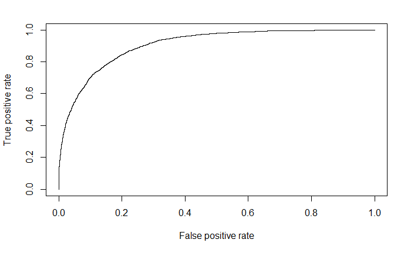

```r
library(ROCR)
ROCR_PredictQ1 <- prediction(Q1predict, Q1test$over50k)
perf1d <- performance(ROCR_PredictQ1, x.measure = "fpr", measure= "tpr")
plot(perf1d)
```

```r
performance(ROCR_PredictQ1, measure = "auc")@y.values
```

```
[[1]]
[1] 0.9061598
```

Area: 0.9061598

5. We have just seen how the logistic regression model for this data achieves a high accuracy. Moreover, the significances of the variables give us a way to gauge which variables are relevant for this prediction task. However, it is not immediately clear which variables are more important than the others, especially due to the large number of factor variables in this problem. Let us now build a classification tree to predict 50k“.
- Use the training set to build the model, and all of the other variables as independent variables.
- Use the default parameters. After you are done building the model, plot the resulting tree.

```r
print(cart1e)
```

```
n= 19187

node), split, n, loss, yval, (yprob)
      * denotes terminal node

 1) root 19187 4617  <=50K (0.75936832 0.24063168)
   2) relationship= Not-in-family, Other-relative, Own-child, Unmarried 10478  702  <=50K (0.93300248 0.06699752)
     4) capitalgain< 7565.5 10297  525  <=50K (0.94901428 0.05098572) *
     5) capitalgain>=7565.5 181    4  >50K (0.02209945 0.97790055) *
   3) relationship= Husband, Wife 8709 3915  <=50K (0.55046504 0.44953496)
     6) education= 10th, 11th, 12th, 1st-4th, 5th-6th, 7th-8th, 9th, Assoc-acdm, Assoc-voc, HS-grad, Preschool, Some-college 6158 2077  <=50K (0.66271517 0.33728483)
      12) capitalgain< 5095.5 5847 1770  <=50K (0.69728066 0.30271934) *
      13) capitalgain>=5095.5 311    4  >50K (0.01286174 0.98713826) *
     7) education= Bachelors, Doctorate, Masters, Prof-school 2551  713  >50K (0.27949824 0.72050176) *
```

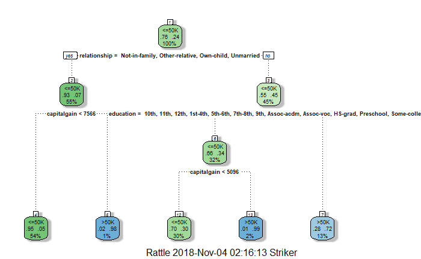

```r
fancyRpartPlot(cart1e)
```

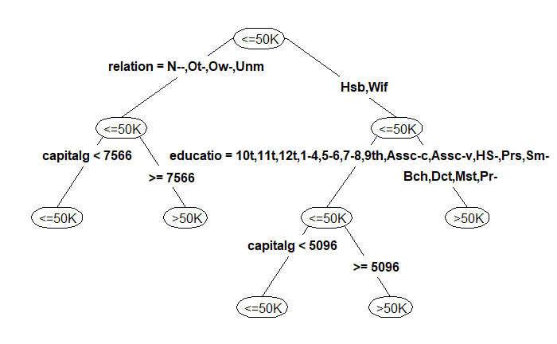

```r
prp(cart1e,type=4)
```

6. How many splits does the tree have in total? 4 splits
7. Which variable does the tree split on at the first level (the very first split of the tree)? relationship
8. Which variables does the tree split on at the second level (immediately after the first split of the tree)? capitalgain and education
9. What is the accuracy of the model on the testing set? Use a threshold of 0.5.

```r
(9243+1596)/(9243+1596+ 470+1482)
```

```
[1] 0.8473927
```

Accuracy = 0.8473927

10. Let us now consider the ROC curve and AUC for the CART model on the test set. You will need to get predicted probabilities for the observations in the test set to build the ROC curve and compute the AUC.
- Plot the ROC curve for the CART model you have estimated. Observe that compared to the logistic regression ROC curve, the CART ROC curve is less smooth. Which of the following explanations for this behavior is most correct?

 The number of variables that the logistic regression model is based on is larger than the number of variables used by the CART model, so the ROC curve for the logistic regression model will be smoother.

 CART models require a higher number of observations in the testing set to produce a smoother/more continuous ROC curve; there is simply not enough data.

 The probabilities from the CART model take only a handful of values (five, one for each end bucket/leaf of the tree); the changes in the ROC curve correspond to setting the threshold to one of those values.

 The CART model uses fewer continuous variables than the logistic regression model (capitalgain for CART versus age, capitalgain, capitallosses, hoursperweek), which is why the CART ROC curve is less smooth than the logistic regression one.

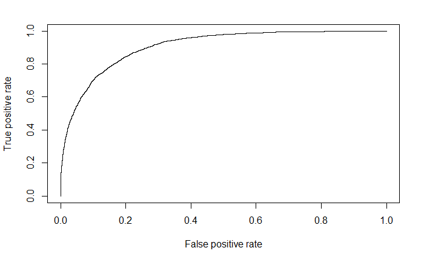

```r
plot(perf1d)
```

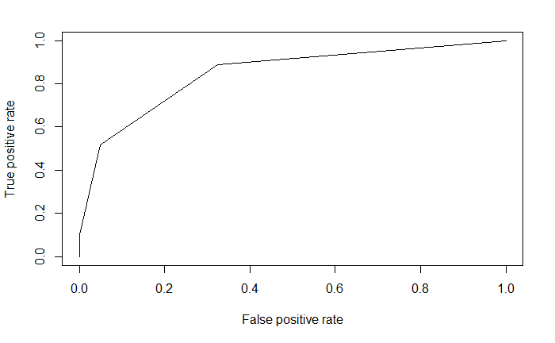

```r
predictcart1_prob <- predict(cart1e, newdata = Q1test, type="prob")
pred_cart1 <- prediction(predictcart1_prob[,2],Q1test$over50k)
perf_cart1 <- performance(pred_cart1, x.measure='fpr',measure = 'tpr')
plot(perf_cart1)
```

3. CART takes only a handful of values.
11. What is the AUC of the CART model on the test set?

```r
performance(pred_cart1,measure="auc")@y.values
```

```
[[1]]
[1] 0.8470256
```

12. Before building a random forest model, we’ll down-sample our training set. While some modern personal computers can build a random forest model on the entire training set, others might run out of memory when trying to train the model since random forests is much more computationally intensive than CART or Logistic Regression. For this reason, before continuing we will define a new training set to be used when building our random forest model, that contains 2000 randomly selected observations from the original training set.
- Do this by running the following commands in your R console (assuming your training set is called “):

```r
set.seed(1)
trainSmall <- Q1train[sample(nrow(Q1train), 2000),]
```

Let us now build a random forest model to predict 50k“, using the dataset ” to build the model. - Set the seed to 1 again right before building the model, and use all of the other variables in the dataset as independent variables. (If you get an error that random forest not handle categorical predictors with more than 32 categories“, rebuild the model without the nativecountry variable as one of the independent variables.) - Then, make predictions using this model on the entire test set. What is the accuracy of the model on the test set, using a threshold of 0.5? (Remember that you don’t need a ” argument when making predictions with a random forest model if you want to use a threshold of 0.5. Also, note that your accuracy might be different from since the random forest models can still differ depending on your operating system, even when the random seed is set.)

```r
library(randomForest)
set.seed(1)
censusrf <- randomForest(over50k~.,data= trainSmall)
pred.rf <- predict(censusrf, newdata = Q1test)
table1l <-  table(Q1test$over50k,pred.rf)
table1l
```

```
        pred.rf
          <=50K  >50K
   <=50K   8843   870
   >50K    1029  2049
```

```r
sum(diag(table1l)/sum(table1l))
```

```
[1] 0.8515362
```

```
      <=50K  >50K
```

<=50K 8843 870 >50K 1029 2049

Acc = 0.8515362

13. As we discussed in class, random forest models work by building a large collection of trees. As a result, we lose some of the interpretability that comes with CART in terms of seeing how predictions are made and which variables are important. However, we can still compute metrics that give us insight into which variables are important. One metric that we can look at is the number of times, aggregated over all of the trees in the random forest model, that a certain variable is selected for a split. To view this metric, run the following lines of R code (replace " with the name of your random forest model):

> vu <- varUsed(MODEL, count=TRUE) vusorted <- sort(vu, decreasing = FALSE, index.return = TRUE) dotchart(vusorted$x, names(MODEL$forest$xlevels[vusorted$ix]))

This code produces a chart that for each variable measures the number of times that variable was selected for splitting (the value on the x-axis). - Which of the variables is the most important in terms of the number of splits?

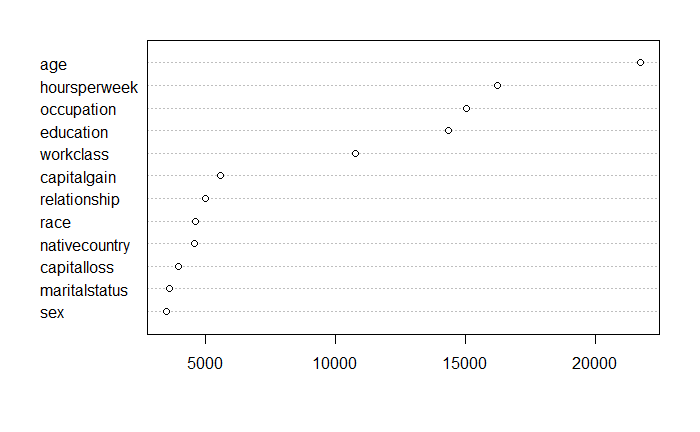

```r
vu <- varUsed(censusrf, count= TRUE)
vusorted <- sort(vu, decreasing = FALSE, index.return = TRUE)
dotchart(vusorted$x, names(censusrf$forest$xlevels[vusorted$ix]))
```

age is the most important variable in random forests in terms of splits

14. A different metric we can look at is related to “, which measures how homogenous each bucket or leaf of the tree is. In each tree in the forest, whenever we select a variable and perform a split, the impurity is decreased. Therefore, one way to measure the importance of a variable is to average the reduction in impurity, taken over all the times that variable is selected for splitting in all of the trees in the forest. To compute this metric, run the following command in R (replace”MODEL" with the name of your random forest model): > varImpPlot(MODEL)
- Which of the following variables is the most important in terms of mean reduction in impurity?

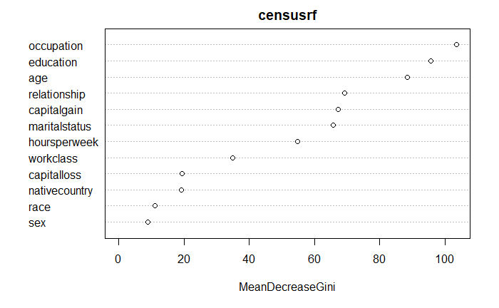

```r
varImpPlot(censusrf)
```

occupation variable is the most important. While age and occupation are important in both models, the order of importance changes.

15. We now conclude our study of this dataset by looking at how CART behaves with different choices of its parameters. Let us select the cost complexity parameter for our CART model using k-fold cross validation, with k = 10 folds. Modify the minimum complexity parameter cp = 0:0001.
- Suggest a reasonable value of the cost complexity parameter from the plot and plot the corresponding tree.

```r
library(rpart)
library(rpart.plot)
tree2 <- rpart(over50k~., data=Q1train, cp = 0.0001)
printcp(tree2)
```

```
Classification tree:
rpart(formula = over50k ~ ., data = Q1train, cp = 1e-04)

Variables actually used in tree construction:
 [1] age           capitalgain   capitalloss   education     hoursperweek  maritalstatus nativecountry occupation    race
[10] relationship  sex           workclass

Root node error: 4617/19187 = 0.24063

n= 19187

           CP nsplit rel error  xerror     xstd
1  0.12183236      0   1.00000 1.00000 0.012825
2  0.06562703      2   0.75634 0.76652 0.011636
3  0.03747022      3   0.69071 0.71648 0.011333
```

[output cut: 31 more lines]

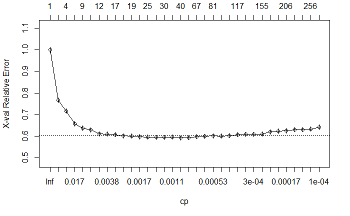

```r
plotcp(tree2)
```

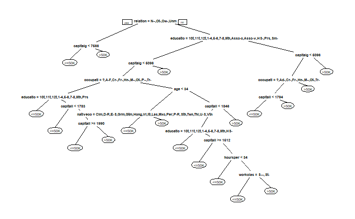

```r
tree1o <- prune(tree2,cp=0.002)
prp(tree1o)
```

16. What is the prediction accuracy on the test set?
- Comment on how the model compares with the model in part (e).

```r
pred.tree1p <- predict(tree1o, newdata = Q1test, type = "class")
table1p <- table(Q1test$over50k,pred.tree1p)
table1p
```

```
        pred.tree1p
          <=50K  >50K
   <=50K   9178   535
   >50K    1240  1838
```

```r
sum(diag(table1p)/sum(table1p))
```

```
[1] 0.8612306
```

```
    pred.tree1p
       <=50K  >50K
```

<=50K 9178 535 >50K 1240 1838 Acc = 0.8612306

Question 2

In this problem, you will fitt regression trees to the Boston dataset. The dataset has the following fields:  crim: per capita crime rate by town  zn: proportion of residential land zoned for lots over 25,000 sq.ft  indus: proportion of non-retail business acres per town  chas: Charles River dummy variable (= 1 if tract bounds river; 0 otherwise)  nox: nitrogen oxides concentration (parts per 10 million)  rm: average number of rooms per dwelling  age: proportion of owner-occupied units built prior to 1940  dis: weighted mean of distances to five Boston employment centres  rad: index of accessibility to radial highways  tax: full-value property-tax rate per $10,000  ptratio: pupil-teacher ratio by town  black: 1000(Bk  0:63)2 where Bk is the proportion of blacks by town  lstat: lower status of the population (percent)  medv: median value of owner-occupied homes in $1000s

```r
boston <- read.csv("Boston.csv")
str(boston)
```

```
'data.frame':   506 obs. of  14 variables:
 $ crim   : num  0.00632 0.02731 0.02729 0.03237 0.06905 ...
 $ zn     : num  18 0 0 0 0 0 12.5 12.5 12.5 12.5 ...
 $ indus  : num  2.31 7.07 7.07 2.18 2.18 2.18 7.87 7.87 7.87 7.87 ...
 $ chas   : int  0 0 0 0 0 0 0 0 0 0 ...
 $ nox    : num  0.538 0.469 0.469 0.458 0.458 0.458 0.524 0.524 0.524 0.524 ...
 $ rm     : num  6.58 6.42 7.18 7 7.15 ...
 $ age    : num  65.2 78.9 61.1 45.8 54.2 58.7 66.6 96.1 100 85.9 ...
 $ dis    : num  4.09 4.97 4.97 6.06 6.06 ...
 $ rad    : int  1 2 2 3 3 3 5 5 5 5 ...
 $ tax    : int  296 242 242 222 222 222 311 311 311 311 ...
 $ ptratio: num  15.3 17.8 17.8 18.7 18.7 18.7 15.2 15.2 15.2 15.2 ...
 $ black  : num  397 397 393 395 397 ...
 $ lstat  : num  4.98 9.14 4.03 2.94 5.33 ...
 $ medv   : num  24 21.6 34.7 33.4 36.2 28.7 22.9 27.1 16.5 18.9 ...
```

We will try to predict the median house value using thirteen predictors

1. Use a seed of 1.
- Split the dataset into a training set and a test set using the sample function where half the observations lie in each set.
- Fit a regression tree to the training set.
- Plot the tree.
- How many predictor variables were used in the regression tree?

```r
#splitting dataset
set.seed(1)
Q2trainid <- sample(1:nrow(boston),0.5*nrow(boston))
Q2testid <- -Q2trainid
Q2train<- boston[Q2trainid,]
Q2test<- boston[Q2testid,]
#fitting regression tree
library(rpart)
library(rpart.plot)
cart2 <- rpart(data=Q2train, medv~.) #using anova because its a regression tree
print(cart2)
```

```
n= 253

node), split, n, deviance, yval
      * denotes terminal node

 1) root 253 20894.66000 22.67312
   2) lstat>=9.715 150  3464.71500 17.55133
     4) lstat>=21.49 30   311.88970 11.10333 *
     5) lstat< 21.49 120  1593.69900 19.16333
      10) lstat>=14.48 58   743.28220 17.15690 *
      11) lstat< 14.48 62   398.48920 21.04032 *
   3) lstat< 9.715 103  7764.58400 30.13204
     6) rm< 7.437 89  3310.16000 27.57640
      12) rm< 6.7815 61  1994.62200 25.52131
        24) dis>=2.85155 54   544.00830 24.32778
          48) rm< 6.36 22    47.17864 21.82273 *
          49) rm>=6.36 32   263.86000 26.05000 *
        25) dis< 2.85155 7   780.27430 34.72857 *
      13) rm>=6.7815 28   496.64960 32.05357 *
     7) rm>=7.437 14   177.84360 46.37857 *
```

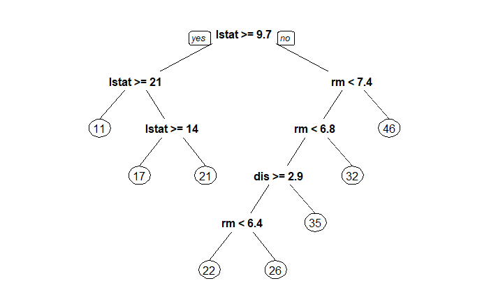

```r
prp(cart2)
```

3 predictor variables were used: lstat, dis and rm

- What is the test set mean squared error?
- Draw a scatter plot of the fitted and true values. On average, the test predictions are within what range of the true median home value for the suburb?

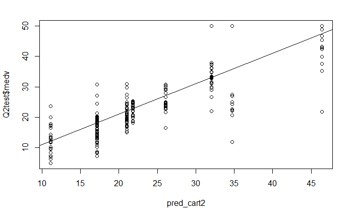

```r
pred_cart2 <- predict(cart2, newdata = Q2test)
mseQ2b <- mean((pred_cart2 -Q2test$medv)^2)
plot(pred_cart2,Q2test$medv)
abline(1:50,1:50)
```

```r
sqrt(mseQ2b)
```

```
[1] 5.035698
```

Test MSE from the regression tree is 25.35. On average, the predictions are within 5.035 of the true value.

3. Use the default settings and cross-validation in order to determine the optimal level of tree complexity.
- Would you prune the tree based on the result?

```r
printcp(cart2)
```

```
Regression tree:
rpart(formula = medv ~ ., data = Q2train)

Variables actually used in tree construction:
[1] dis   lstat rm

Root node error: 20895/253 = 82.588

n= 253

        CP nsplit rel error  xerror     xstd
1 0.462576      0   1.00000 1.01273 0.117728
2 0.204673      1   0.53742 0.56339 0.059699
3 0.074618      2   0.33275 0.34949 0.039945
4 0.039191      3   0.25813 0.29608 0.039976
5 0.032082      4   0.21894 0.31072 0.048076
6 0.021629      5   0.18686 0.29508 0.048053
7 0.011150      6   0.16523 0.26146 0.042604
8 0.010000      7   0.15408 0.25032 0.037014
```

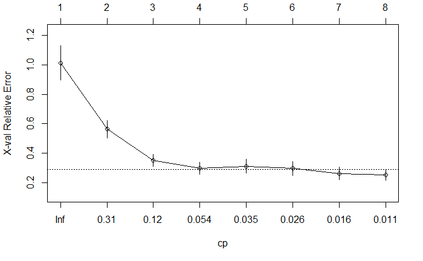

```r
plotcp(cart2)
```

By using the default settings, we see that te smallest value of xerror (or xerror + xstd) is given at cp = 0:01 (7 splits). Hence, we would not prune the tree developed earlier

4. Suppose you prune the tree to 5 nodes. Plot the new tree. What is the test set mean squared error? Compare with the result in part (b).

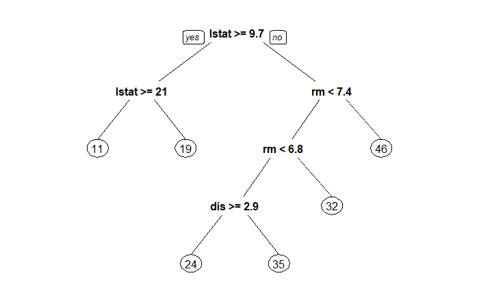

```r
cart2d <- prune(cart2,cp=0.021629)
prp(cart2d)
```

```r
pred_cart2d <- predict(cart2d, newdata = Q2test)
mseQ2d <- mean((pred_cart2d-Q2test$medv)^2)
mseQ2d
```

```
[1] 28.25719
```

MSE = 28.25719

5. Use random forests to analyze this data.
- Set the seed to 1 before running the method.
- What test set mean squared error do you obtain?
- How does this compare to the CART model?
- How many variables does the randomForest function try at each split?

```r
set.seed(1)
library(randomForest)
forest2e <- randomForest(medv~. , data = Q2train)
forest2e
```

```
Call:
 randomForest(formula = medv ~ ., data = Q2train)
               Type of random forest: regression
                     Number of trees: 500
No. of variables tried at each split: 4

          Mean of squared residuals: 12.80249
                    % Var explained: 84.5
```

```r
pred.forest2e <- predict(forest2e, newdata = Q2test)
table_forest2e <- table(Q2test$medv, pred.forest2e)
mseQ2e <- mean((pred.forest2e-Q2test$medv)^2)
mseQ2e
```

```
[1] 11.68218
```

RF NSE = 11.68218 vs CART MSE = 28.25719

The result from the random forest, in terms of test error, is significantly smaller than CART. It tries 4 variables at each split by default. .

6. Use the importance() function to determine the two variables which are most important. Plot the importance measures using the varImpPlot().

```r
importance(forest2e)
```

```
        IncNodePurity
crim        1280.4199
zn           103.2912
indus       1241.2864
chas         121.2697
nox         1166.6627
rm          5533.0713
age          704.6916
dis         1454.6769
rad          123.1168
tax          791.3915
ptratio     1334.1137
black        462.2710
lstat       6010.6947
```

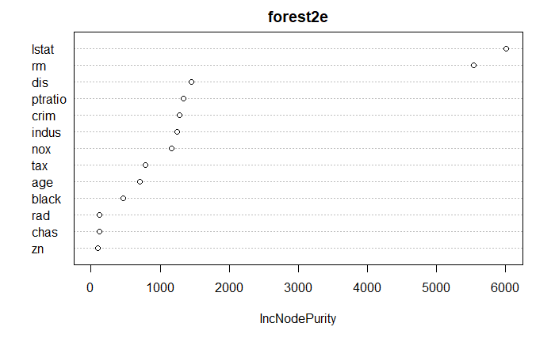

```r
varImpPlot(forest2e)
```

The highest values are obtained for lstat and rm (most important).

7. Describe the effect of the number of variables considered at each split controlled by the mtry argument in randomForest(), on the error obtained.

By default, random forests use p/3 variables in regression and sqrt(p) variables in classification, where p is the number of variables to randomly sample as candidates at each split. Here, 13/3 =~ 4, as in part (e).

We can try out different values of mtry arguments in random forests to control this. Using all variables gives highly correlated trees, and as such, the prediction power of such a model would not be as good.

```r
set.seed(1)
forest2g_1 <- randomForest(medv~., data = Q2train, mtry = 6)
forest2g_1
```

```
Call:
 randomForest(formula = medv ~ ., data = Q2train, mtry = 6)
               Type of random forest: regression
                     Number of trees: 500
No. of variables tried at each split: 6

          Mean of squared residuals: 11.5574
                    % Var explained: 86.01
```

```r
pred_forest2g_1 <- predict(forest2g_1, newdata = Q2test)
mse2g_1 <- mean((pred_forest2g_1 - Q2test$medv)^2)
mse2g_1
```

```
[1] 11.64505
```

```r
set.seed(1)
forest2g_2 <- randomForest(medv~., data = Q2train, mtry = 13)
forest2g_2
```

```
Call:
 randomForest(formula = medv ~ ., data = Q2train, mtry = 13)
               Type of random forest: regression
                     Number of trees: 500
No. of variables tried at each split: 13

          Mean of squared residuals: 10.60749
                    % Var explained: 87.16
```

```r
pred_forest2g_2 <- predict(forest2g_2, newdata = Q2test)
mse2g_2 <- mean((pred_forest2g_2 - Q2test$medv)^2)
mse2g_2
```

```
[1] 13.2573
```

Question 3

3. In this question, we will look at the data on the US Supreme Court decisions from 1994 to 2001 and build a predictive model to forecast Supreme Court decisions. The data is provided in the file supremeexercise.csv and contains the following variables:  docket: Case number  term: Case year  party 1: First party in the case  party 2: Second party in the case  rehndir: Direction of Judge Rehnquist ruling (1 = conservative, 0 = liberal)  stevdir: Direction of Judge Stevens ruling (1 = conservative, 0 = liberal)  ocondir: Direction of Judge O’Connors ruling (1 = conservative, 0 = liberal)  scaldir: Direction of Judge Scalia ruling (1 = conservative, 0 = liberal)  kendir: Direction of Judge Kennedy ruling (1 = conservative, 0 = liberal)  soutdir: Direction of Judge Souter ruling (1 = conservative, 0 = liberal)  thomdir: Direction of Judge Thomas ruling (1 = conservative, 0 = liberal)  gindir: Direction of Judge Ginsburg ruling (1 = conservative, 0 = liberal)  brydir: Direction of Judge Breyer ruling (1 = conservative, 0 = liberal)  petit: Petitioner type (BUSINESS, CITY, DEF (defendant), EE (employee), ER (employer), INDIAN, IP (injured person), OF (offcial), OTHER, POL (politician), STATE, US)  respon: Respondent type (Same as petitioner types)  circuit: Circuit of origin of case (1st-11th, DC, and FED)  unconst: Case argued to be as unconstitutional by law by petitioner (1 = yes, 0 = no)  lctdir: Lower Court direction of ruling (liberal, conser)  issue: Issue of the case (AT = attorneys, CP = criminal procedure, CR = civil rights, DP = due process, ECN = economic activity, FA = first amendment, FED = federalism, IR = interstate relations, JUD = judicial power, PRIV = privacy, TAX = federal taxation, UN = unions)  result: Result of the case (1 = conservative, 0 = liberal)
1. Read the data into the dataframe supreme. What is the fraction of cases in which the Supreme Court reversed the decision of the Lower Court?

```r
supreme <- read.csv("supremeexercise.csv")
str(supreme)
```

```
'data.frame':   598 obs. of  20 variables:
 $ docket : Factor w/ 598 levels "00-1011","00-1021",..: 93 94 95 96 97 98 99 100 101 102 ...
 $ term   : int  1994 1994 1994 1994 1994 1994 1994 1994 1994 1994 ...
 $ party_1: Factor w/ 209 levels "0","AC","AG",..: 75 78 201 194 88 12 84 194 89 194 ...
 $ party_2: Factor w/ 202 levels "AC","AIRLINE",..: 54 133 195 188 83 91 81 177 183 1 ...
 $ rehndir: int  1 0 0 1 1 1 1 1 1 1 ...
 $ stevdir: int  0 0 0 0 0 1 1 0 1 0 ...
 $ ocondir: int  1 0 0 0 1 0 0 1 1 1 ...
 $ scaldir: int  1 1 0 1 1 1 0 1 1 1 ...
 $ kendir : int  1 0 0 0 0 1 1 1 1 1 ...
 $ soutdir: int  1 0 0 0 0 0 0 0 1 0 ...
 $ thomdir: int  1 1 0 1 1 1 0 1 1 1 ...
 $ gindir : int  1 0 0 0 0 1 1 0 1 1 ...
 $ brydir : int  1 0 0 0 0 0 1 0 1 1 ...
 $ petit  : Factor w/ 12 levels "BUSINESS","CITY",..: 1 9 9 12 4 9 9 12 9 12 ...
 $ respon : Factor w/ 12 levels "BUSINESS","CITY",..: 1 9 9 9 9 9 1 9 1 3 ...
 $ circuit: Factor w/ 13 levels "10th","11th",..: 13 2 13 12 5 8 8 7 11 11 ...
 $ unconst: int  0 0 0 0 0 0 0 0 0 0 ...
 $ lctdir : Factor w/ 2 levels "conser","liberal": 2 1 2 2 1 1 2 1 2 2 ...
 $ issue  : Factor w/ 12 levels "AT","CP","CR",..: 5 5 3 6 5 3 9 7 11 2 ...
 $ result : int  1 0 0 0 0 1 1 1 1 1 ...
```

```r
tableA <- table(supreme$lctdir,supreme$result)
tableA
```

```
            0   1
  conser  170 136
  liberal  94 198
```

```r
sum(diag(tableA)/sum(tableA))
```

```
[1] 0.6153846
```

```
      lib  cons
        0   1
```

conser 170 136 liberal 94 198

Fraction reversed = 0.6153846

2. Define a new variable unCons that takes a value of 1 if the decision made by the judges was an unanimous conservative decision and 0 otherwise.
- Write down the R command(s) that you used to define this variable.
- What is the total number of cases that had an unanimous conservative decision?

```r
table(supreme$unCons)
```

```
  0   1
455 143
```

0 1 455 143

143 Cases.

3. Define a new variable unLib that takes a value of 1 if the decision made by the judges was an unanimous liberal decision and 0 otherwise.
- What is the total number of cases that had an unanimous liberal decision?

```r
table(supreme$unLib)
```

```
  0   1
474 124
```

0 1 474 124

124 Cases.

4. You will now develop a two step CART model for this data. In the first step, you will build two classification trees to predict the unanimous conservative and liberal decisions respectively and in the second step, you will build nine judge-specific trees to predict the outcome for cases for which the predictions from the first step are ambiguous.
- Start by building a CART model to predict unCons using the six predictor variables petit, respon, circuit, unconst, lctdir and issue.
- Use the rpart package in R to build the model.
- Use the default parameter settings to build the CART model.
- Remember that you want to build a classification tree rather than a regression tree.
- Use all the observations to build the model. – How many node splits are there in the resulting tree?

```r
library(rpart)
library(rpart.plot)
Q1d_cons <- rpart(data = supreme, unCons~petit+respon+circuit+unconst+lctdir+issue,method="class")
Q1d_lib <- rpart(data = supreme, unLib~petit+respon+circuit+unconst+lctdir+issue,method="class")
printcp(Q1d_cons)
```

```
Classification tree:
rpart(formula = unCons ~ petit + respon + circuit + unconst +
    lctdir + issue, data = supreme, method = "class")

Variables actually used in tree construction:
[1] circuit issue   petit   respon

Root node error: 143/598 = 0.23913

n= 598

        CP nsplit rel error xerror     xstd
1 0.017483      0   1.00000 1.0000 0.072944
2 0.013986      2   0.96503 1.1259 0.075852
3 0.010000      7   0.87413 1.2587 0.078440
```

```r
printcp(Q1d_lib)
```

```
Classification tree:
rpart(formula = unLib ~ petit + respon + circuit + unconst +
    lctdir + issue, data = supreme, method = "class")

Variables actually used in tree construction:
[1] circuit issue   petit   respon

Root node error: 124/598 = 0.20736

n= 598

        CP nsplit rel error  xerror     xstd
1 0.040323      0   1.00000 1.00000 0.079952
2 0.012097      2   0.91935 0.96774 0.078983
3 0.010000      6   0.87097 1.12903 0.083507
```

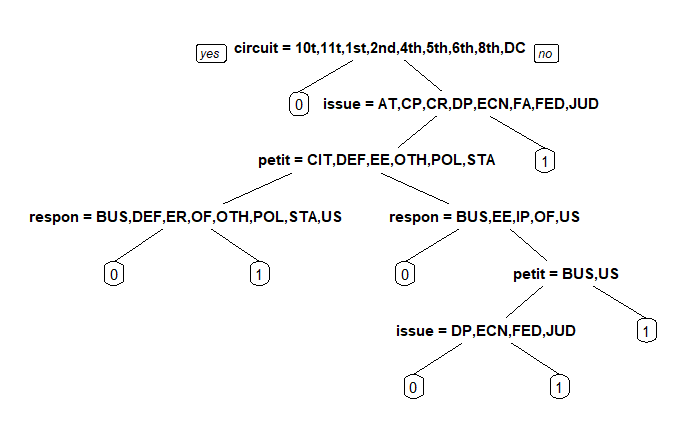

```r
prp(Q1d_cons)
```

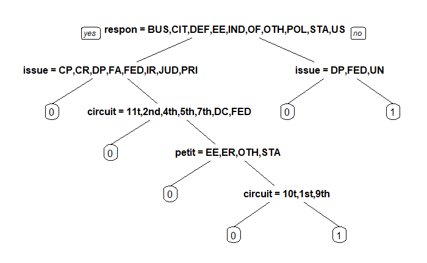

```r
prp(Q1d_lib)
```

There are 7 splits for the unCons tree

5. List all the variables that this tree splits on. circuit, issue, petit, respon
6. What is the area under the curve for the receiver operating characteristic (ROC) curve for this model?

```r
performance(pred_uncons,measure="auc")@y.values
```

```
[[1]]
[1] 0.6519788
```

AOC = 0.6519788

7. Similarly build a CART model to predict unLib using the six variables petit, respon, circuit, unconst, lctdir and issue as the predictor variables.
- Use the default parameter settings to build the CART model.
- Use all the observations to build the model.
- Which variable does the tree split on at the first level?

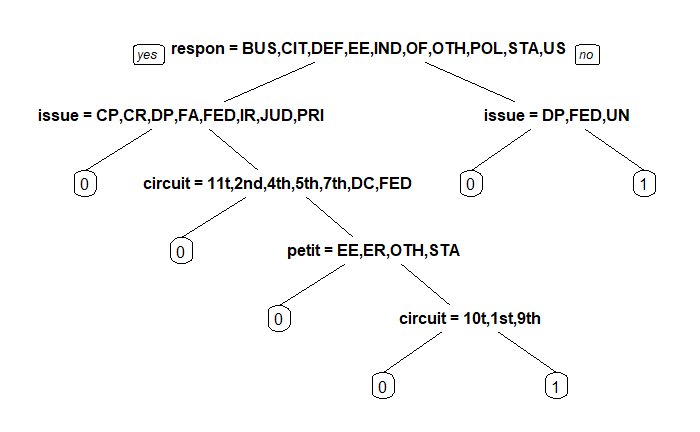

The first level is split using the variable respon

8. Using the CART tree plot for the model in question (g), identify the leaf node with the fewest number of observations in it.
- What is the fraction of cases that has an unanimous liberal decision at this node?

```r
print(Q1d_lib)
```

```
n= 598

node), split, n, loss, yval, (yprob)
      * denotes terminal node

 1) root 598 124 0 (0.7926421 0.2073579)
   2) respon=BUSINESS,CITY,DEF,EE,INDIAN,OF,OTHER,POL,STATE,US 563 104 0 (0.8152753 0.1847247)
     4) issue=CP,CR,DP,FA,FED,IR,JUD,PRIV 431  63 0 (0.8538283 0.1461717) *
     5) issue=AT,ECN,TAX,UN 132  41 0 (0.6893939 0.3106061)
      10) circuit=11th,2nd,4th,5th,7th,DC,FED 67  15 0 (0.7761194 0.2238806) *
      11) circuit=10th,1st,3rd,6th,8th,9th 65  26 0 (0.6000000 0.4000000)
        22) petit=EE,ER,OTHER,STATE 34   9 0 (0.7352941 0.2647059) *
        23) petit=BUSINESS,IP,OF,US 31  14 1 (0.4516129 0.5483871)
          46) circuit=10th,1st,9th 17   7 0 (0.5882353 0.4117647) *
          47) circuit=3rd,6th,8th 14   4 1 (0.2857143 0.7142857) *
   3) respon=ER,IP 35  15 1 (0.4285714 0.5714286)
     6) issue=DP,FED,UN 11   3 0 (0.7272727 0.2727273) *
     7) issue=CP,CR,ECN,JUD,TAX 24   7 1 (0.2916667 0.7083333) *
```

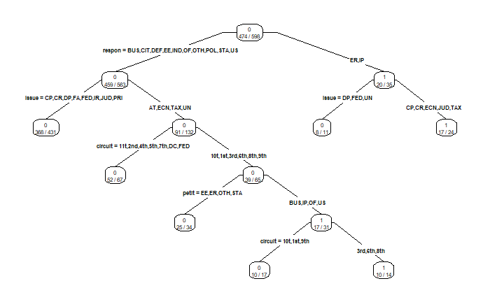

```r
prp(Q1d_lib,type=4,extra=2)
```

Node 6) has the least observations.

The output for this node is “0” for not-unanimous liberal. Here 3 observations are misclassified to the node. Meaning that these 3 are actually unanimous liberal decisions.

1. We will now combine the results from the two trees.
- What is the total number of cases where the two trees predict an unanimous outcome for the conservative and liberal judgement simultaneously, thus contradicting each other?

```r
Qi_predict_uncons<- predict(Q1d_cons, newdata = supreme, type = "class")
Qi_predict_lib<- predict(Q1d_lib, newdata = supreme, type = "class")
i1 <- as.integer(Qi_predict_uncons)-1
i2 <- as.integer(Qi_predict_lib)-1
table(i1,i2)
```

```
   i2
i1    0   1
  0 502  36
  1  58   2
```

```
  0   1
```

0 502 36 1 58 2

There are 2 cases where unanimous conservative and liberal decisions were predicted by the trees

10. What is the total number of cases where neither tree predicts an unanimous outcome? 502 cases (from table above)
11. We now build the second part of our model which is nine judge-specific classification trees to provide predictions for the cases when either both trees predict an unanimous outcome or neither does (the harder cases).
- Build a CART model to predict each of the variables rehndir up to brydir using the six predictor variables petit, respon, circuit, unconst, lctdir and issue.
- Build your model using only those cases identified in questions (i) and (j).
- Use the majority of the judge predictions to make a prediction for each of these cases.
- What is the accuracy of the model on these cases?

```r
tablek <- table(totalcons>=5,supreme1$result)
tablek
```

```
          0   1
  FALSE 149  71
  TRUE   73 211
```

```r
sum(diag(tablek)/sum(tablek))
```

```
[1] 0.7142857
```

```
      0   1
```

FALSE 149 71 TRUE 73 211

Accuracy = 0.7142857

12. What is the overall accuracy of your two step CART model?

```r
598-504
```

[output not shown]

```
[1] 94
```

13. We consider the Moseley versus Victoria Secret Catalogue case in 2002, the details of which are as follows: The owner of the ’s Secret" business brought a trademark dilution action against Victor Moseley in the Lower Court. They claimed that the ’s Secret" trademark was diluted and tarnished by Moseley’s adult specialty business named ’s Secret“. The U.S. Lower Court for the Sixth Circuit ruled the judgment in a conservative direction by ruling in favor of Victoria’s Secret. Moseley petitioned against this decision to the Supreme Court.
- Use your two step model to predict the outcome of this case which deals with economic activities. You can look at the tree plots to make your conclusion.

petit = BUSINESS respon = BUSINESS circuit = 6th unconst = 0? lctdir= conser issue = ECN

Using the tree Q1d_cons, we get a prediction of 0 for unanimous conservative Using the tree Q1d_lib, we get a prediction of 1 for unanimous liberal

Hence via the prediction system we get a unanimous vote for liberal decision, overturning the lower court decision

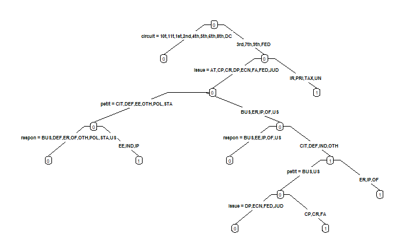

```r
prp(Q1d_cons,type=4)
```

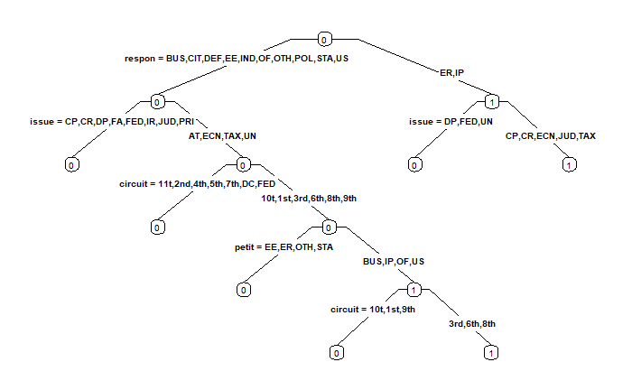

```r
prp(Q1d_lib,type=4)
```

14. We will now build a random forest model directly to predict the outcome result using the six predictor variables petit, respon, circuit, unconst, lctdir and issue.
- Use all the observations to build you model.
- Use the default settings to build the random forest model.
- What is the accuracy of the model?

```r
library(randomForest)
set.seed(1)
forest3 <- randomForest(data = supreme, as.factor(result)~petit+respon+circuit+unconst+lctdir+issue)
forest_pred <- predict(forest3,newdata=supreme)
tablen <- table(forest_pred,supreme$result)
tablen
```

```
forest_pred   0   1
          0 229  24
          1  35 310
```

```r
sum(diag(tablen)/sum(tablen))
```

```
[1] 0.9013378
```

forest_pred 0 1 0 229 24 1 35 310 [1] 0.9013378

15. The CART model and the random forest models have their respective advantages. Briefy provide one reason each as to why the CART model might be preferred to the random forest model and one reason why the random forest model might be preferred to the CART model.

CART is more interpretable than the random forest, but the latter has a greater accuracy.